# Reproducible Research Assignment 2: Tornadoes Threaten People, Property, and Crops

## Synopsis

This was written for Course Project 2 of the Johns Hopkins/Coursera Reproducible Research Course. Based on simple analysis of totals across the timeframe of the data in question, the analysis answers the questions below:

- Across the US, which types of events are most harmful with respect to population health?
  - Tornadoes
- Across the US, which types of events have the greatest economic consequences?
  - Tornadoes, TSTM Wind, Hail

This analysis relies on data provided by the U.S. National Oceanic Atmospheric Administration’s (NOAA) storm database.

## Requirements

The code is this document was generated in RStudio. It requires the knitr, ggplot2, dplyr, reshape2, and gridArrange packages.

## Data Processing

The data processing step begins by downloading the data from the website provided in the assignment and reading it into R.

### Initial processing

```r
library(knitr)
library(dplyr)
```

```r
library(ggplot2)
library(reshape2)
library(gridExtra)
fileURL<-"https://d396qusza40orc.cloudfront.net/repdata%2Fdata%2FStormData.csv.bz2"
download.file(fileURL,destfile = "fstormdata.csv.bz2")
stormdata<-read.csv("fstormdata.csv.bz2")
```

#### Data exploration to inform data processing

```r
str(stormdata)
```

```
## 'data.frame':    902297 obs. of  37 variables:
##  $ STATE__   : num  1 1 1 1 1 1 1 1 1 1 ...
##  $ BGN_DATE  : Factor w/ 16335 levels "1/1/1966 0:00:00",..: 6523 6523 4242 11116 2224 2224 2260 383 3980 3980 ...
##  $ BGN_TIME  : Factor w/ 3608 levels "00:00:00 AM",..: 272 287 2705 1683 2584 3186 242 1683 3186 3186 ...
##  $ TIME_ZONE : Factor w/ 22 levels "ADT","AKS","AST",..: 7 7 7 7 7 7 7 7 7 7 ...
##  $ COUNTY    : num  97 3 57 89 43 77 9 123 125 57 ...
##  $ COUNTYNAME: Factor w/ 29601 levels "","5NM E OF MACKINAC BRIDGE TO PRESQUE ISLE LT MI",..: 13513 1873 4598 10592 4372 10094 1973 23873 24418 4598 ...
##  $ STATE     : Factor w/ 72 levels "AK","AL","AM",..: 2 2 2 2 2 2 2 2 2 2 ...
##  $ EVTYPE    : Factor w/ 985 levels "   HIGH SURF ADVISORY",..: 834 834 834 834 834 834 834 834 834 834 ...
##  $ BGN_RANGE : num  0 0 0 0 0 0 0 0 0 0 ...
##  $ BGN_AZI   : Factor w/ 35 levels "","  N"," NW",..: 1 1 1 1 1 1 1 1 1 1 ...
##  $ BGN_LOCATI: Factor w/ 54429 levels "","- 1 N Albion",..: 1 1 1 1 1 1 1 1 1 1 ...
##  $ END_DATE  : Factor w/ 6663 levels "","1/1/1993 0:00:00",..: 1 1 1 1 1 1 1 1 1 1 ...
##  $ END_TIME  : Factor w/ 3647 levels ""," 0900CST",..: 1 1 1 1 1 1 1 1 1 1 ...
##  $ COUNTY_END: num  0 0 0 0 0 0 0 0 0 0 ...
```

[output cut: 23 more lines]

The data set is very large, composed of numeric and factor variables. For basic analyses of human health and economic costs associated with different event types, the key variables are EVTYPE (events), FATALITIES, INJURIES, PROPDMG, PROPMGEXP (the cost of property damage incurred in significant digits, and a multiplier value, respectively), CROPDMG, and CROPDMGEXP (the costs of crop damage incurred in significant digs, and a multiplier value, respectively).

### Further processing

The only processing required for analysis of human health is aggregation of the fatality and injury data (performed below).

```r
#create event table for question one
by_event<- summarize(group_by(stormdata,EVTYPE),tot_fatalities=sum(FATALITIES), avg_fatalities=mean(FATALITIES), tot_injuries=sum(INJURIES), avg_injuries=mean(INJURIES))
mby_event<-melt(by_event,id="EVTYPE")
```

In order to obtain comparable values for analysis of economic damage, the data on property and crop damage must be converted by their respective multipliers, and then combined into a single damage value variable. The three values described in the NOAA codebook for these data are “k” for thousands, “m” for millions, and “b” for billions. The actual data contain additional values, including various symbols and numbers. However, their prevalence is low and even if included, would create such small values as to have minimal impact on analysis, so for this anlaysis I convert any data which has a multiplier on than that specified in the codebook to “NA”.

```r
# create data for second part of analysis
# only calculate for data with multipliers for thousand, million, or billion; other values treated as NA
stormdata$propdmgcalc <- as.numeric(NA)
stormdata$cropdmgcalc <- as.numeric(NA)
for(i in 1:nrow(stormdata)){
  if(stormdata$PROPDMGEXP[i]=="k" | stormdata$PROPDMGEXP[i]=="K"){
    stormdata$propdmgcalc[i]<-stormdata$PROPDMG[i]*1000
    }
  if(stormdata$PROPDMGEXP[i]=="m" | stormdata$PROPDMGEXP[i]=="M"){
    stormdata$propdmgcalc[i]<-stormdata$PROPDMG[i]*1000000
    }
  if(stormdata$PROPDMGEXP[i]=="b" | stormdata$PROPDMGEXP[i]=="B"){
    stormdata$propdmgcalc[i]<-stormdata$PROPDMG[i]*1000000000
    }
  if(stormdata$CROPDMGEXP[i]=="k" | stormdata$CROPDMGEXP[i]=="K"){
    stormdata$cropdmgcalc[i]<-stormdata$CROPDMG[i]*1000
    }
  if(stormdata$CROPDMGEXP[i]=="m" | stormdata$CROPDMGEXP[i]=="M"){
    stormdata$cropdmgcalc[i]<-stormdata$CROPDMG[i]*1000000
    }
  if(stormdata$CROPDMGEXP[i]=="b" | stormdata$CROPDMGEXP[i]=="B"){
    stormdata$cropdmgcalc[i]<-stormdata$CROPDMG[i]*1000000000
    }
}
```

### Analysis of and correction for outliers

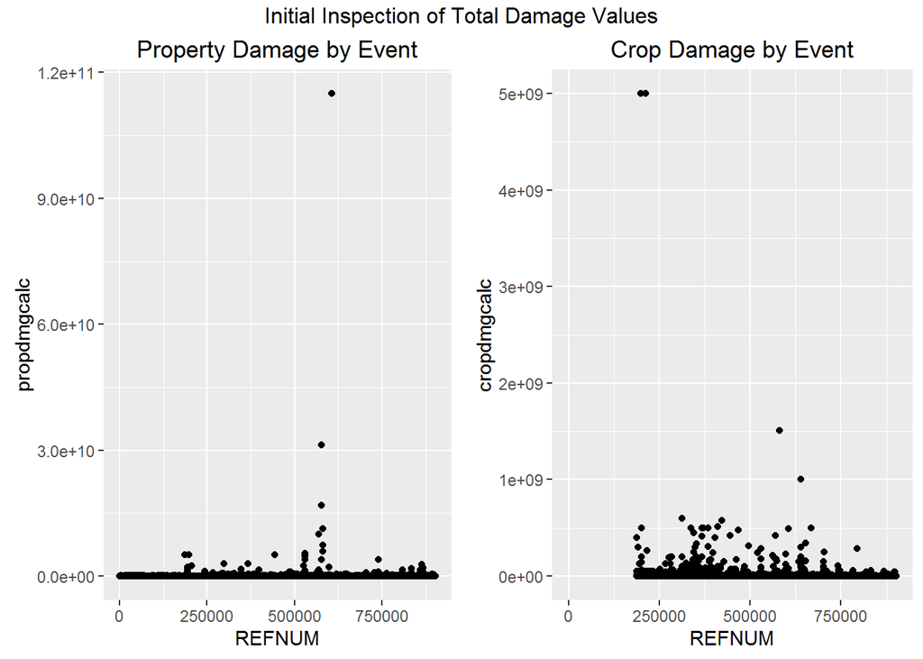

```r
prop_explore<-qplot(REFNUM,propdmgcalc,data=stormdata, main="Property Damage by Event")
crop_explore<-qplot(REFNUM,cropdmgcalc,data=stormdata, main="Crop Damage by Event")
grid.arrange(prop_explore,crop_explore,ncol=2,top="Initial Inspection of Total Damage Values")
```

Initial exloration of the damage data shows outliers; both property damage and crop damage plots show values far exceeding the rest of the data based on initial visual inspection. In the case of the crop damage, the two detailed remarks (not shown for here for brevity) do not immediately indicate a data entry error, and so the outliers are left in the dataset. However, for the property damage outlier, the remarks indicate that the damage was in the millions, while the multiplier in the data is for billion.

```r
stormdata$REMARKS<-as.character(stormdata$REMARKS)
outlier_refnum<-stormdata[which(stormdata$propdmgcalc==max(stormdata$propdmgcalc,na.rm=TRUE)),"REFNUM"]
stormdata[which(stormdata$REFNUM==outlier_refnum),"REMARKS"]
```

```
## [1] "Major flooding continued into the early hours of January 1st, before the Napa River finally fell below flood stage and the water receeded. Flooding was severe in Downtown Napa from the Napa Creek and the City and Parks Department was hit with $6 million in damage alone. The City of Napa had …
```

Thus, I correct that field to “m” and update the calculated values for that result.

```r
stormdata[which(stormdata$REFNUM==outlier_refnum),"PROPDMGEXP"]<-"m"
stormdata[which(stormdata$REFNUM==outlier_refnum),"propdmgcalc"]<-stormdata[which(stormdata$REFNUM==outlier_refnum),"PROPDMG"]*1000000
```

### Final Cleanup

Those calculated costs are combined into a total cost variable for each event, and the data are then aggregated by event to form the data frame use in answering question two.

```r
byevent_costs<- summarise(group_by(stormdata,EVTYPE),tot_propcost=sum(propdmgcalc),avg_propcost=mean(propdmgcalc), tot_cropcost=sum(cropdmgcalc),avg_cropcost=mean(cropdmgcalc))
byevent_costs$combcost_calc<-byevent_costs$tot_propcost+byevent_costs$tot_cropcost
```

## Results

For simplicity, I choose to use total values across the history provided in the data set to determine threat to health and economic harm. However, I also provide averages from all events in the data for comparison.

### Question One - Population Health

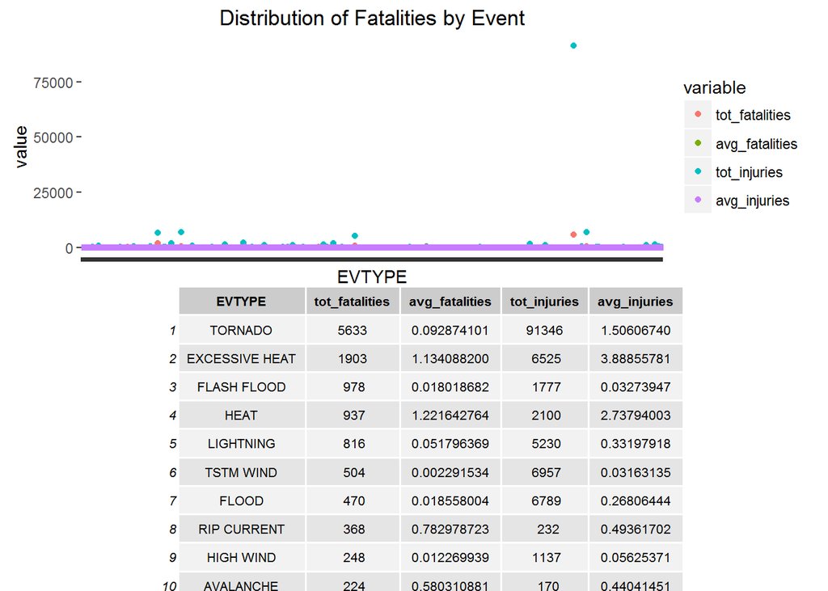

```r
fatality_tabledata<-by_event %>% arrange(desc(tot_fatalities)) %>% head(n=10)
fatalityplot<- qplot(EVTYPE,value,data=mby_event,color=variable, main="Distribution of Fatalities by Event")+theme(axis.text.x=element_blank())
mytheme<-ttheme_default(base_size = 8)
fatalitytable<-tableGrob(d=fatality_tabledata,theme=mytheme)
grid.arrange(fatalityplot,fatalitytable,nrow=2)
```

Based on total deaths over time, the event category TORNADO has posed the most harm to population health.

### Question Two - Economic Consequences

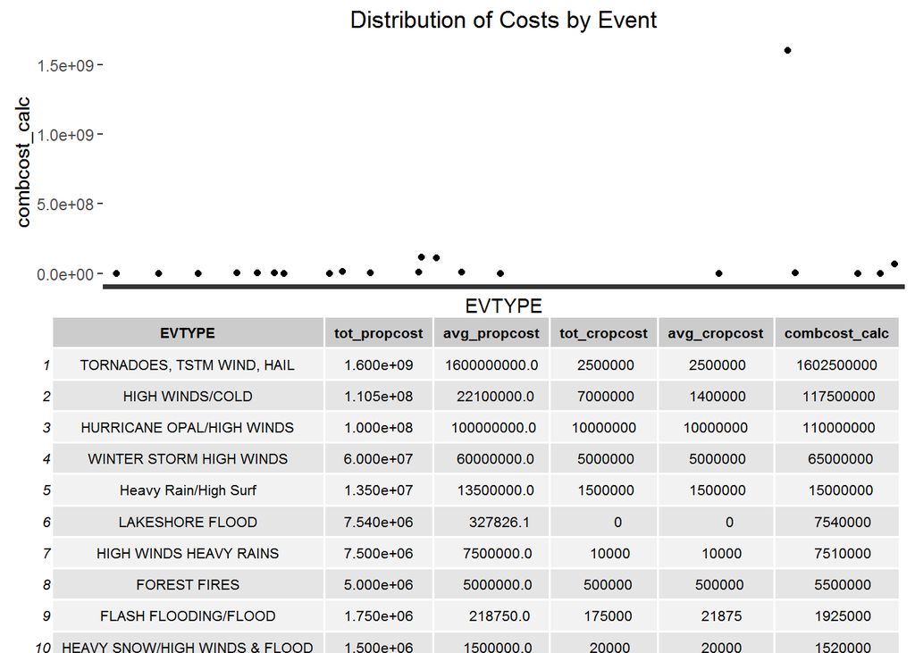

```r
totalcost_tabledata<-byevent_costs %>% arrange(desc(combcost_calc)) %>% head(n=10)
costplot<-qplot(EVTYPE, combcost_calc, data=byevent_costs, main="Distribution of Costs by Event")+ theme(axis.text.x=element_blank())
mytheme<-ttheme_default(base_size = 8)
costtable<-tableGrob(d=totalcost_tabledata, theme=mytheme)
grid.arrange(costplot,costtable,nrow=2)
```

Based on total costs over time (both property and crop), the event category TORNADOES, TSTM WIND, HAIL has caused the greatest economic consequences.